# R Notebook

# Load in libraries

```r
library(tidyverse)
library(janitor)
library(lubridate)
```

# Read in data

```r
flights <- read_csv("clean_data/flights_clean.csv")
airlines <- read_csv("raw_data/airlines.csv")
airports <- read_csv("raw_data/airports.csv")
weather <- read_csv("clean_data/weather_clean.csv")
nyc_daily_weather <- read_csv("raw_data/daily_weather_data_2017.csv")
additional_weather <- read_csv("clean_data/additional_weather.csv")
planes <- read_csv("clean_data/planes_clean.csv")
daily_weather <- read_csv("clean_data/daily_weather.csv")
# combine flights and planes data
flights_planes <- flights %>%
  left_join(planes, "tailnum") %>%
  filter(origin == "EWR") %>%
  mutate(across(where(is.character), ~as_factor(.x))) %>%
  drop_na()


model1_base_data <- flights_planes %>%
  left_join(weather, c("time_hour", "origin")) %>%
  left_join(additional_weather, c("time_hour" = "datetime")) %>%
  left_join(daily_weather, c("date", "origin")) %>%
  drop_na() %>%
  select(-time_hour, -origin, -dest, -dep_delay, -wind_gust, -tailnum, -seats,
         -manufacturer, -wind_dir, -date)
```

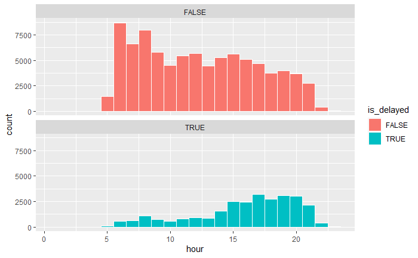

```r
# daily variance in number of delayed flights - Newark
flights %>%
  filter(!is.na(is_delayed)) %>%
  filter(origin == "EWR") %>%
  # group_by(sched_dep_hour) %>%
  # mutate(props_delayed)
  # filter(dep_delay > 0) %>%
  ggplot(aes(x = hour, fill = is_delayed)) +
  geom_histogram(col = "white", binwidth = 1) +
  facet_wrap(~is_delayed, nrow = 3)
```

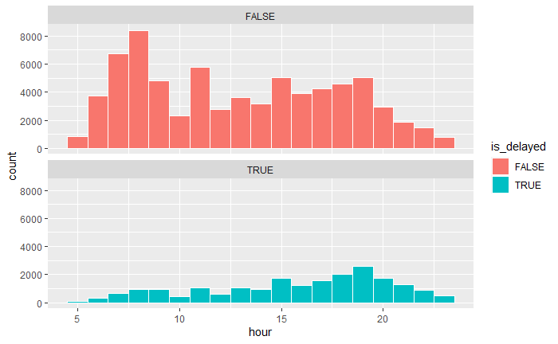

```r
# daily variance in number of delayed flights - JFK
flights %>%
  filter(!is.na(is_delayed)) %>%
  filter(origin == "JFK") %>%
  # group_by(sched_dep_hour) %>%
  # mutate(props_delayed)
  # filter(dep_delay > 0) %>%
  ggplot(aes(x = hour, fill = is_delayed)) +
  geom_histogram(col = "white", binwidth = 1) +
  facet_wrap(~is_delayed, nrow = 3)
```

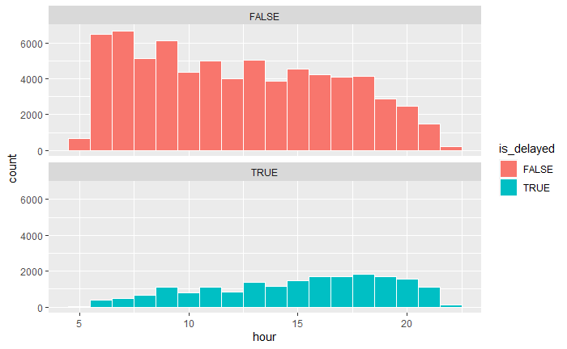

```r
# daily variance in number of delayed flights - LGA
flights %>%
  filter(!is.na(is_delayed)) %>%
  filter(origin == "LGA") %>%
  # group_by(sched_dep_hour) %>%
  # mutate(props_delayed)
  # filter(dep_delay > 0) %>%
  ggplot(aes(x = hour, fill = is_delayed)) +
  geom_histogram(col = "white", binwidth = 1) +
  facet_wrap(~is_delayed, nrow = 3)
```

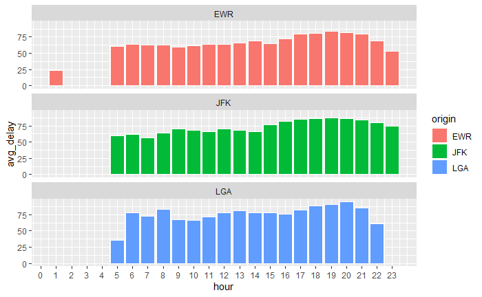

```r
# average delay in mins throughout the day
flights %>%
  filter(is_delayed == 1) %>%
  group_by(origin, hour) %>%
  summarise(avg_delay = mean(dep_delay)) %>%
  ggplot(aes(x = hour, y = avg_delay, fill = origin)) +
  geom_col(col = "white", binwidth = 1) +
  facet_wrap(~origin, ncol = 1) +
  scale_x_continuous(breaks = 0:23)
```

[output not shown]

# Delays and cancellations per airline

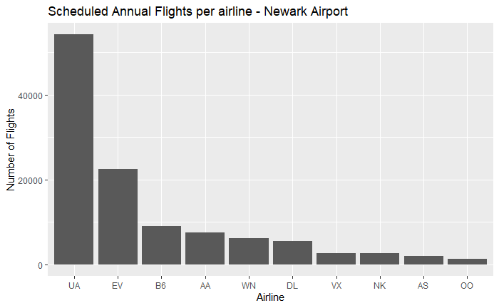

```r
# total number of flights scheduled per airline - Newark
flights %>%
  filter(origin == "EWR") %>%
  group_by(carrier) %>%
  summarise(total_scheduled_flights = n()) %>%
  ggplot(aes(x = reorder(carrier, - total_scheduled_flights),
             y = total_scheduled_flights)) +
  geom_col() +
  labs(title = "Scheduled Annual Flights per airline - Newark Airport",
       x = "Airline",
       y = "Number of Flights")
```

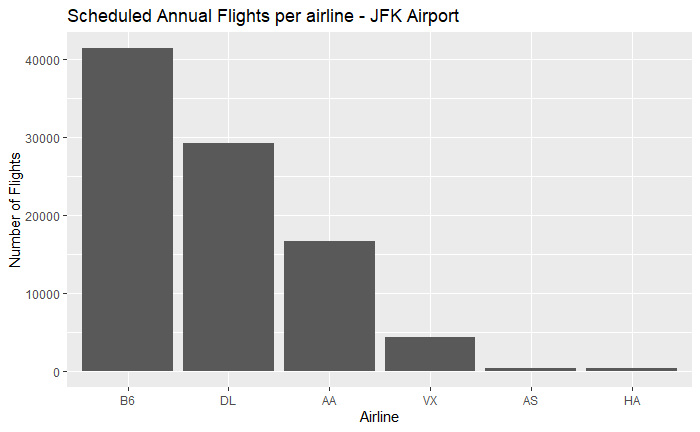

```r
# total number of flights scheduled per airline - JFK
flights %>%
  filter(origin == "JFK") %>%
  group_by(carrier) %>%
  summarise(total_scheduled_flights = n()) %>%
  ggplot(aes(x = reorder(carrier, - total_scheduled_flights),
             y = total_scheduled_flights)) +
  geom_col() +
  labs(title = "Scheduled Annual Flights per airline - JFK Airport",
       x = "Airline",
       y = "Number of Flights")
```

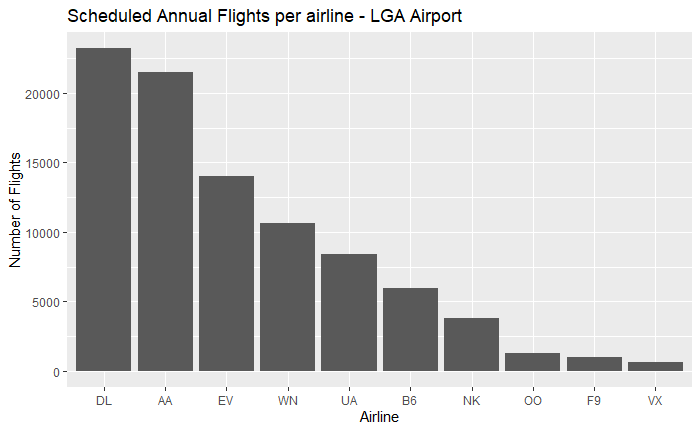

```r
# total number of flights scheduled per airline - LGA
flights %>%
  filter(origin == "LGA") %>%
  group_by(carrier) %>%
  summarise(total_scheduled_flights = n()) %>%
  ggplot(aes(x = reorder(carrier, - total_scheduled_flights),
             y = total_scheduled_flights)) +
  geom_col() +
  labs(title = "Scheduled Annual Flights per airline - LGA Airport",
       x = "Airline",
       y = "Number of Flights")
```

# Dealing with missing values

It is assumed that the weather between the 3 NY airports are similar so any missing values for: - wind_dir (wind direction) - wind_speed - wind_gust - visib

Will be replaced by the average of the other airports data for that date.

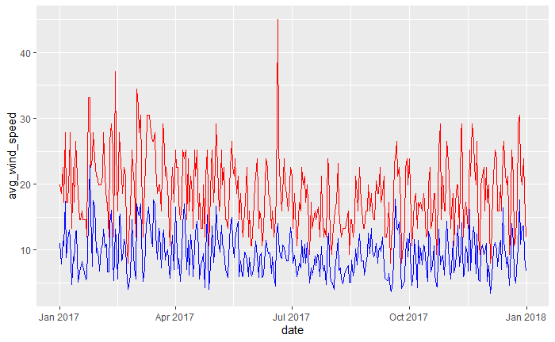

```r
daily_weather_data <- weather %>%
  mutate(date = as_date(time_hour)) %>%
  group_by(date, origin) %>%
  summarise(avg_wind_speed = mean(wind_speed),
            max_wind_speed = max(wind_gust),
            avg_visib = mean(visib)) %>%
  left_join(daily_weather, c("date", "origin"))
# avg and max wind speeds
daily_weather_data %>%
  filter(origin == "EWR") %>%
  ggplot(aes(x = date)) +
  geom_line(aes(y = avg_wind_speed), col = "blue") +
  geom_line(aes(y = max_wind_speed), col = "red")
```

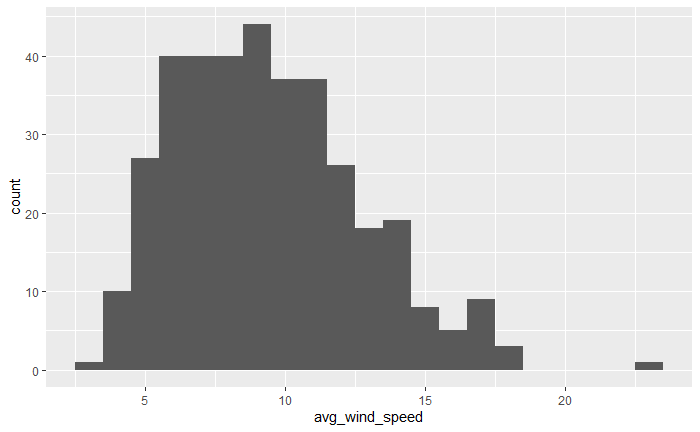

```r
daily_weather_data %>%
  filter(origin == "EWR") %>%
  ggplot(aes(x = avg_wind_speed)) +
  geom_histogram(binwidth = 1) # normal distribution with positive skew
```

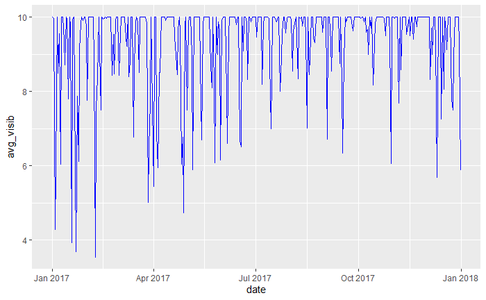

```r
# avg visibility
daily_weather_data %>%
  filter(origin == "EWR") %>%
  ggplot(aes(x = date)) +
  geom_line(aes(y = avg_visib), col = "blue")
```

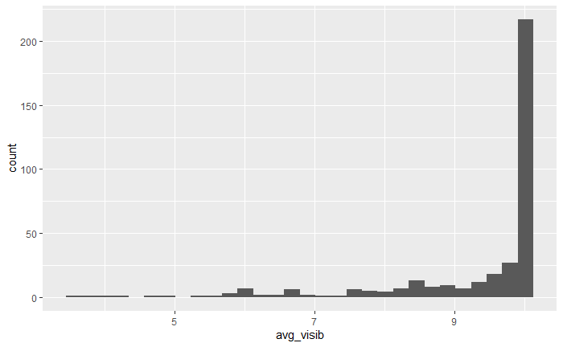

```r
daily_weather_data %>%
  filter(origin == "EWR") %>%
  ggplot(aes(x = avg_visib)) +
  geom_histogram() # predominantly 10 (max value), long tail to the left
```

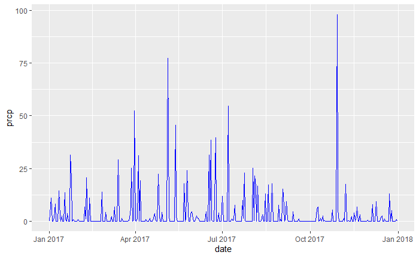

```r
# avg_precip
daily_weather_data %>%
  filter(origin == "EWR") %>%
  ggplot(aes(x = date)) +
  geom_line(aes(y = prcp), col = "blue")
```

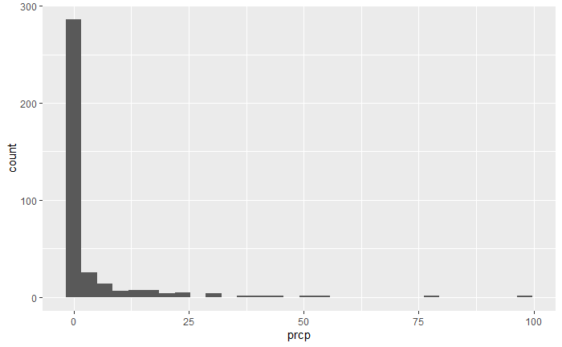

```r
daily_weather_data %>%
  filter(origin == "EWR") %>%
  ggplot(aes(x = prcp)) +
  geom_histogram() # predominantly 0 (min value), long tail to the right
```

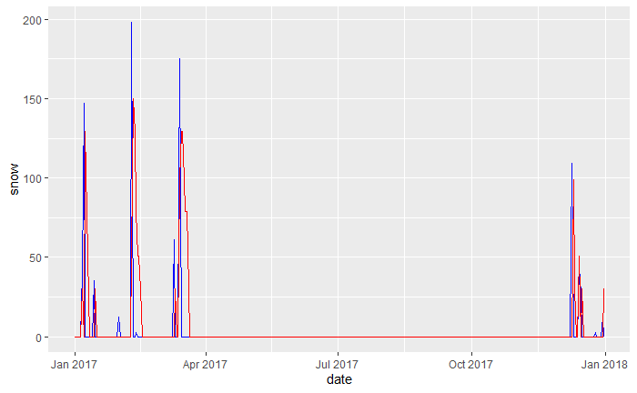

```r
# snow and snow depths
daily_weather_data %>%
  filter(origin == "EWR") %>%
  ggplot(aes(x = date)) +
  geom_line(aes(y = snow), col = "blue") +
  geom_line(aes(y = snow_depth), col = "red")
```

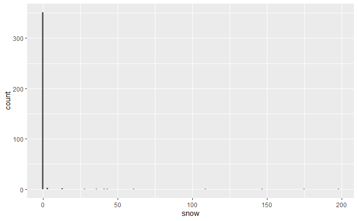

```r
# there's always a lag between snowfall and snow depth indicating the build up
# of snow and subsequent melting of snow

daily_weather_data %>%
  filter(origin == "EWR") %>%
  ggplot(aes(x = snow)) +
  geom_histogram(binwidth = 1) # mostly 0 values, skewed to the right.
```

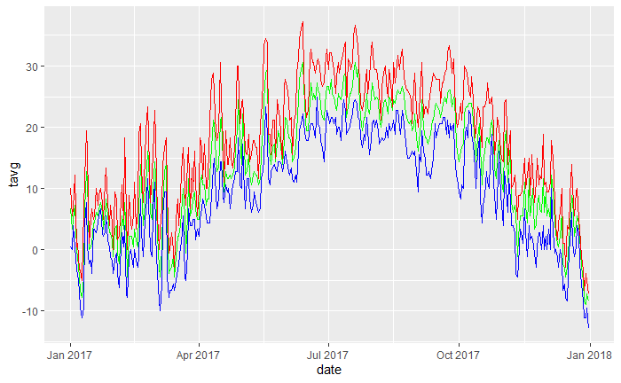

```r
# min, avg and max temperature
daily_weather_data %>%
  filter(origin == "EWR") %>%
  ggplot(aes(x = date)) +
  geom_line(aes(y = tavg), col = "green") +
  geom_line(aes(y = tmax), col = "red") +
  geom_line(aes(y = tmin), col = "blue")
```

# Analysis of Weather Data - Newark Airport

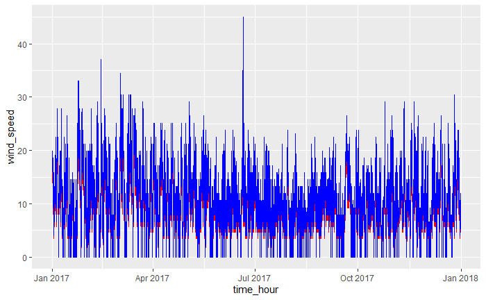

```r
# wind_speed
weather %>%
  filter(origin == "EWR") %>%
  ggplot(aes(x = time_hour)) +
  geom_line(aes(y = wind_speed), col = "red") +
  geom_line(aes(y = wind_gust), col = "blue")
```

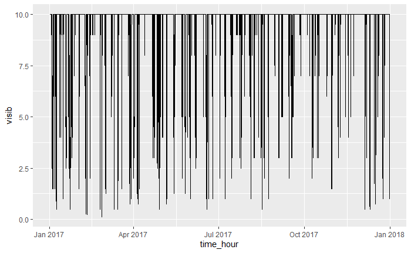

```r
# wind_gust
weather %>%
  filter(origin == "EWR") %>%
  ggplot(aes(x = time_hour, y = visib)) +
  geom_line()
```

# Summary Statistics for flights and delays

```r
# annual flights
flights %>%
  group_by(origin) %>%
  summarise(count = n())
```

| origin | count |
| --- | --- |
| EWR | 113067 |
| JFK | 92481 |
| LGA | 90390 |

```r
NA
```

## Number of passengers and passengers affected by delays

```r
planes <- read_csv("clean_data/planes_clean.csv")
flights %>%
  left_join(planes, "tailnum") %>%
  group_by(origin, is_delayed) %>%
  summarise(max_passengers = sum(seats, na.rm = TRUE)) %>%
  pivot_wider(names_from = is_delayed, values_from = max_passengers,
              names_prefix = "x") %>%
  mutate(total_passengers = xTRUE + xFALSE,
         prop_pass_delayed = xTRUE / total_passengers)
```

| origin | xFALSE | xTRUE | total_passengers | prop_pass_delayed |
| --- | --- | --- | --- | --- |
| EWR | 12283238 | 3865642 | 16148880 | 0.2393752 |
| JFK | 9348818 | 2695427 | 12044245 | 0.2237938 |
| LGA | 8072939 | 2202655 | 10275594 | 0.2143579 |

## Number of monthly flights

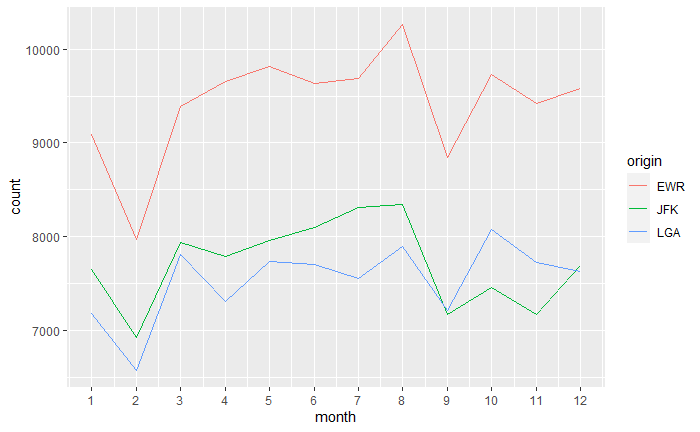

```r
flights %>%
  group_by(origin, month) %>%
  summarise(count = n()) %>%
  ggplot(aes(x = month, y = count, colour = origin)) +
  geom_line() +
  scale_x_continuous(breaks = 1:12)
```

Newark has the highest number of flights in NY with approximately 10,000 per month between March and August. There is a peak in August.

```r
flights %>%
  filter(is.na(is_delayed))
```

| time_hour | date | wday | month | hour | origin | dest | dep_delay | carrier | tailnum | is_delayed |
| --- | --- | --- | --- | --- | --- | --- | --- | --- | --- | --- |

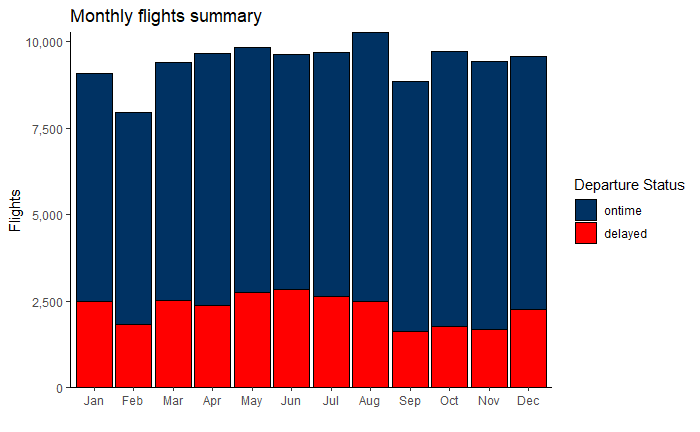

```r
flights %>%
  filter(origin == "EWR") %>%
  group_by(month) %>%
  summarise(total_flights = n(),
            delayed = sum(is_delayed)) %>%
  mutate(ontime = total_flights - delayed,
         month = month(month, label = TRUE)) %>%
  select(-total_flights) %>%
  pivot_longer(c(ontime, delayed), names_to = "flight_type",
               values_to = "num") %>%
  mutate(flight_type = factor(flight_type, levels = c("ontime", "delayed"))) %>%
  ggplot(aes(x = month, y = num, fill = flight_type)) +
  geom_col(col = "black") +
  scale_fill_manual(values = c("ontime" = "#003263",
                                "delayed" = "red")) +
  scale_y_continuous(labels = scales::comma, expand = c(0,0)) +
  labs(title = "Monthly flights summary",
       x = "",
       y = "Flights",
       fill = "Departure Status") +
  theme_classic()
```

```r
daily_weather
```

| date | origin | prcp | snow | snow_depth | tavg | tmax | tmin | has_weather_warning |
| --- | --- | --- | --- | --- | --- | --- | --- | --- |
| 2017-01-01 | EWR | 0.000 | 0.00 | 0.00 | 6.6666667 | 10.0000000 | 0.5555556 | FALSE |
| 2017-01-02 | EWR | 7.366 | 0.00 | 0.00 | 3.3333333 | 5.5555556 | 0.0000000 | TRUE |
| 2017-01-03 | EWR | 10.922 | 0.00 | 0.00 | 5.0000000 | 6.6666667 | 3.8888889 | TRUE |
| 2017-01-04 | EWR | 0.000 | 0.00 | 0.00 | 7.2222222 | 12.2222222 | 0.5555556 | TRUE |
| 2017-01-05 | EWR | 0.000 | 0.00 | 0.00 | 0.0000000 | 0.5555556 | -3.3333333 | FALSE |
| 2017-01-06 | EWR | 1.524 | 40.64 | 30.48 | -1.1111111 | 1.1111111 | -3.8888889 | TRUE |
| 2017-01-07 | EWR | 8.128 | 147.32 | 0.00 | -4.4444444 | -3.3333333 | -6.6666667 | TRUE |
| 2017-01-08 | EWR | 0.000 | 0.00 | 129.54 | -6.6666667 | -3.3333333 | -9.4444444 | FALSE |
| 2017-01-09 | EWR | 0.000 | 0.00 | 78.74 | -7.7777778 | -5.0000000 | -11.1111111 | FALSE |
| 2017-01-10 | EWR | 0.000 | 0.00 | 50.80 | -4.4444444 | 6.6666667 | -9.4444444 | FALSE |

[output cut: 990 more lines]

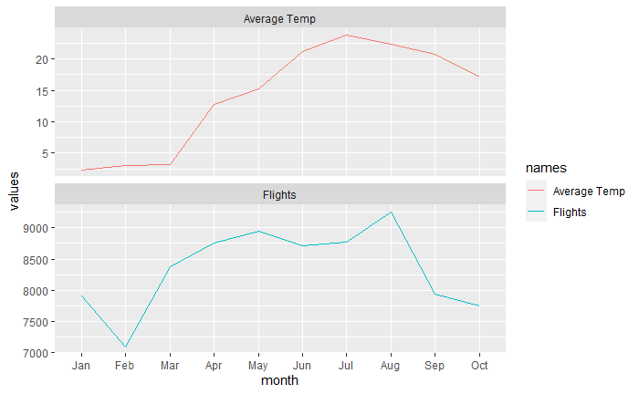

```r
model1_base_data %>%
  mutate(month = month(month, label = TRUE)) %>%
  group_by(month) %>%
  summarise("Average Temp" = mean(temperature),
            "Flights" = n()) %>%
  pivot_longer("Average Temp":"Flights", names_to = "names",
               values_to = "values") %>%
  ggplot(aes(x = month, y = values, col = names, group = names)) +
  geom_line() +
  facet_wrap(~names, ncol = 1, scales = "free_y")
```

## Proportion of flights which are delayed across 3 NY airports.

```r
flights %>%
  group_by(origin) %>%
  summarise(n = n(), prop_delayed = mean(is_delayed, na.rm = TRUE))
```

| origin | n | prop_delayed |
| --- | --- | --- |
| EWR | 113067 | 0.2408749 |
| JFK | 92481 | 0.2214185 |
| LGA | 90390 | 0.2109857 |

```r
NA
```

Newark Airport flights are delayed 24.1 of the time whereas JFK has only 22.1% delayed flights and La Guardia has 21.1% delayed flights. Newark has the highest proportion of delayed flights of the 3 airports compared here but the most flights. So why?

## Which routes are delayed the most?

```r
flights %>%
  group_by(origin, dest) %>%
  summarise(prop_delayed = mean(is_delayed, na.rm = TRUE)) %>%
  pivot_wider(names_from = origin, values_from = prop_delayed) %>%
  arrange(desc(EWR)) %>%
  left_join(airports, by = c("dest" = "faa")) %>%
  select(dest, name, EWR, JFK, LGA)
```

| dest | name | EWR | JFK | LGA |
| --- | --- | --- | --- | --- |
| DSM | Des Moines International Airport | 0.53284672 | NA | NA |
| FWA | Fort Wayne International Airport | 0.49538462 | NA | NA |
| FNT | Bishop International Airport | 0.47663551 | NA | NA |
| SBN | South Bend Regional Airport | 0.42755344 | NA | 0.00000000 |
| BQN | NA | 0.37818182 | 0.2640187 | NA |
| SMF | Sacramento International Airport | 0.36585366 | 0.3853503 | NA |
| CAK | Akron Canton Regional Airport | 0.35109718 | NA | NA |
| MKE | General Mitchell International Airport | 0.33946078 | NA | 0.27136150 |
| BWI | Baltimore/Washington International Thurgood Marshall Airport | 0.33675565 | NA | NA |
| XNA | Northwest Arkansas Regional Airport | 0.33333333 | NA | 0.37301587 |

[output cut: 99 more lines]

## Average Delay Length

| origin | avg_dep_delay | med_dep_delay |
| --- | --- | --- |
| EWR | 74.03995 | 51 |
| JFK | 77.48821 | 50 |
| LGA | 80.68502 | 52 |

## Average monthly delay time

```r
monthly_delays <- flights %>%
  group_by(origin, month) %>%
  filter(dep_delay > 0) %>%
  summarise(avg_dep_delay = mean(dep_delay),
            med_dep_delay = median(dep_delay),
            count = n())
monthly_delays
```

| origin | month | avg_dep_delay | med_dep_delay | count |
| --- | --- | --- | --- | --- |
| EWR | 1 | 41.19944 | 21 | 4317 |
| EWR | 2 | 41.86419 | 21 | 3181 |
| EWR | 3 | 45.46539 | 23 | 4190 |
| EWR | 4 | 47.41878 | 23 | 3952 |
| EWR | 5 | 52.98556 | 30 | 4225 |
| EWR | 6 | 56.93289 | 31 | 4247 |
| EWR | 7 | 61.77733 | 33 | 3934 |
| EWR | 8 | 56.10804 | 28 | 3758 |
| EWR | 9 | 46.17109 | 27 | 2560 |
| EWR | 10 | 43.50999 | 24 | 2902 |

[output cut: 26 more lines]

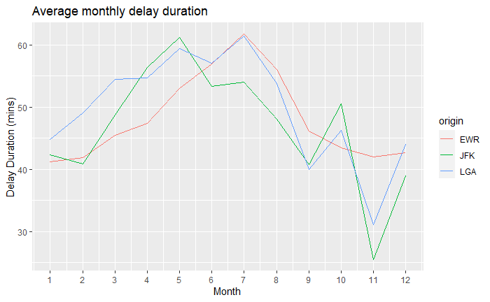

```r
monthly_delays %>%
  ggplot(aes(x = month, y = avg_dep_delay, col = origin)) +
  geom_line() +
  scale_x_continuous(breaks = 1:12) +
  labs(title = "Average monthly delay duration",
       x = "Month",
       y = "Delay Duration (mins)")
```

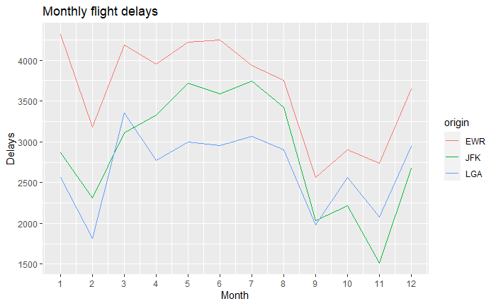

```r
# this needs to be updated to be delay = 15+ mins
monthly_delays %>%
  ggplot(aes(x = month, y = count, col = origin)) +
  geom_line() +
  scale_x_continuous(breaks = 1:12) +
  labs(title = "Monthly flight delays",
       x = "Month",
       y = "Delays")
```

The average monthly delay duration peaks in the summer in July, showing a strong seasonal variation. However, the number of flight delays stays high from March to August (~4000 delayed flights per month). This tells us that despite July not being the month with the most delays, there must be something else which is causing the delays to be on average, longer in this month. For example, there is a significant spike in the number of delays in December and January however the average delay durations are at an annual low (around 43mins) compared to the peak in July of 62 mins.

## Are there any planes which are delayed more frequently?

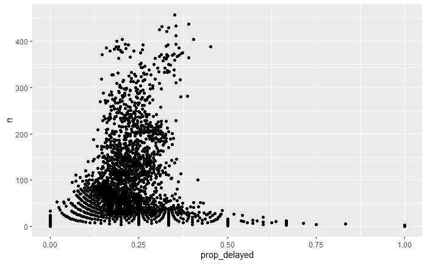

```r
flights %>%
  group_by(tailnum) %>%
  summarise(prop_delayed = mean(is_delayed, na.rm = TRUE),
            n = n(),
            num_delayed = prop_delayed * n) %>%
  arrange(desc(n), desc(prop_delayed)) %>%
  ggplot(aes(y = n, x = prop_delayed)) +
  geom_point()
```

```r
NA
NA
```

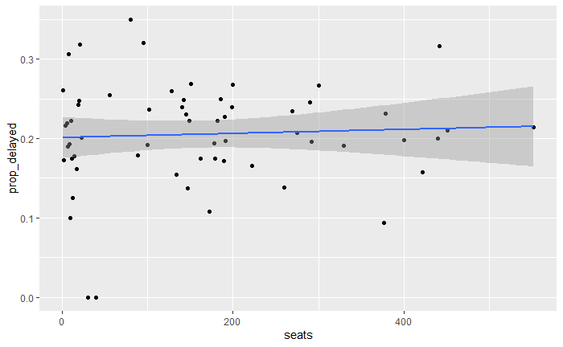

```r
# are larger planes delayed more often?
flights %>%
  left_join(planes, "tailnum") %>%
  group_by(seats) %>%
  summarise(prop_delayed = mean(is_delayed, na.rm = TRUE)) %>%
  ggplot(aes(x = seats, y = prop_delayed)) +
  geom_point() +
  geom_smooth(method = "lm")
```

Runways: Newark: 290 & 40 JFK & LGA: 310 & 40

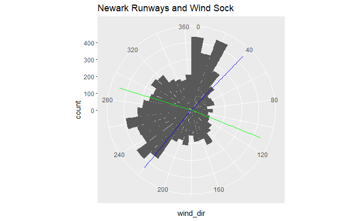

```r
# newark runways and wind map
weather %>%
  filter(origin == "EWR") %>%
  ggplot(aes(x = wind_dir)) +
  geom_histogram(binwidth = 10) +
  coord_polar() +
  scale_x_continuous(n.breaks = 12) +
  # add runway 4 (40 degrees)
  geom_vline(xintercept = 40, col = "blue") +
  geom_vline(xintercept = 220, col = "blue") +
  # add Newark runway 29 (290 degrees)
  geom_vline(xintercept = 290, col = "green") +
  geom_vline(xintercept = 110, col = "green") +
  labs(title = "Newark Runways and Wind Sock")
```

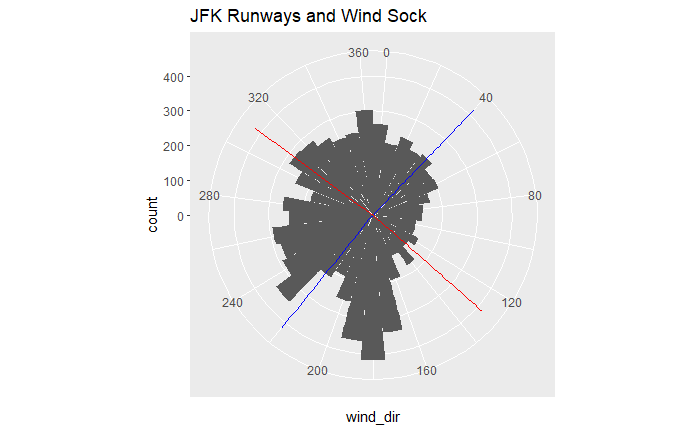

```r
# JFK runway and wind map
weather %>%
  filter(origin == "JFK") %>%
  ggplot(aes(x = wind_dir)) +
  geom_histogram(binwidth = 10) +
  coord_polar() +
  scale_x_continuous(n.breaks = 12) +
  # add runway 4 (40 degrees)
  geom_vline(xintercept = 40, col = "blue") +
  geom_vline(xintercept = 220, col = "blue") +
  # add JFK & LGA runway 31 (310 degrees)
  geom_vline(xintercept = 310, col = "red") +
  geom_vline(xintercept = 130, col = "red") +
  labs(title = "JFK Runways and Wind Sock")
```

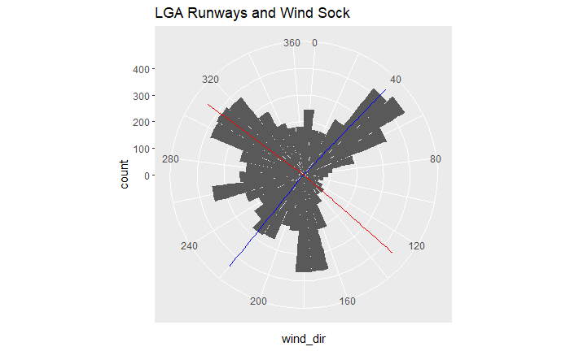

```r
# LGA runway and wind map
weather %>%
  filter(origin == "LGA") %>%
  ggplot(aes(x = wind_dir)) +
  geom_histogram(binwidth = 10) +
  coord_polar() +
  scale_x_continuous(n.breaks = 12) +
  # add runway 4 (40 degrees)
  geom_vline(xintercept = 40, col = "blue") +
  geom_vline(xintercept = 220, col = "blue") +
  # add JFK & LGA runway 31 (310 degrees)
  geom_vline(xintercept = 310, col = "red") +
  geom_vline(xintercept = 130, col = "red") +
  labs(title = "LGA Runways and Wind Sock")
```

```r
avg_wind_dir <- weather %>%
  group_by(origin) %>%
  mutate(wind_dir = if_else(wind_dir < 180, wind_dir + 360, wind_dir)) %>%
  summarise(avg_wind_dir = mean(wind_dir))

avg_wind_dir
```

| origin | avg_wind_dir |
| --- | --- |
| EWR | 335.0438 |
| JFK | 335.1257 |
| LGA | 338.1190 |

```r
NA
NA
```

Appears to be spikes in the frequency of wind direction for 310 and 40 (which matches well with the runway angles). However, 2017 saw quite a large proportion of wind directions heading 335 degrees. Newark runways have the biggest difference between runway angle and wind_dir which may be a reason for the number of delays at Newark.

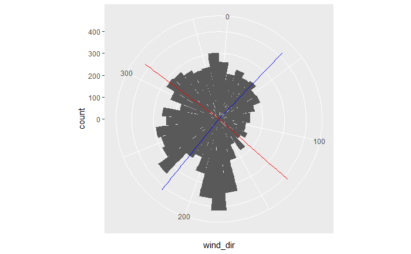

```r
weather %>%
  # full_join(weather_clean, "time_hour") %>%
  # select(origin.x, wind_dir.x, wind_dir.y, time_hour) %>%
  filter(origin == "JFK") %>%
  #filter(!is.na(wind_dir.x)) %>%
  ggplot(aes(x = wind_dir)) +
  geom_histogram(binwidth = 10) +
  coord_polar() +
    # add runway 4 (40 degrees)
  geom_vline(xintercept = 40, col = "blue") +
  geom_vline(xintercept = 220, col = "blue") +
  # add JFK & LGA runway 31 (310 degrees)
  geom_vline(xintercept = 310, col = "red") +
  geom_vline(xintercept = 130, col = "red")
```

```r
weather %>%
  filter(origin == "JFK") %>% # 8,733
  filter(!is.na(wind_dir)) # 7,861 (90%)
```

| time_hour | origin | wind_dir | wind_speed | wind_gust | visib | min_wind_dev | wind_magnitude |
| --- | --- | --- | --- | --- | --- | --- | --- |
| 2017-01-01 08:00:00 | JFK | 200 | 16.11092 | 18.540125 | 10.00 | 20 | 322.2184 |
| 2017-01-01 09:00:00 | JFK | 220 | 14.96014 | 17.215830 | 10.00 | 0 | 0.0000 |
| 2017-01-01 10:00:00 | JFK | 200 | 14.96014 | 17.215830 | 10.00 | 20 | 299.2028 |
| 2017-01-01 11:00:00 | JFK | 220 | 13.80936 | 15.891535 | 10.00 | 0 | 0.0000 |
| 2017-01-01 12:00:00 | JFK | 220 | 12.65858 | 14.567241 | 10.00 | 0 | 0.0000 |
| 2017-01-01 13:00:00 | JFK | 220 | 11.50780 | 13.242946 | 10.00 | 0 | 0.0000 |
| 2017-01-01 14:00:00 | JFK | 240 | 11.50780 | 13.242946 | 10.00 | 20 | 230.1560 |
| 2017-01-01 15:00:00 | JFK | 240 | 11.50780 | 13.242946 | 10.00 | 20 | 230.1560 |
| 2017-01-01 16:00:00 | JFK | 220 | 9.20624 | 10.594357 | 10.00 | 0 | 0.0000 |
| 2017-01-01 17:00:00 | JFK | 230 | 10.35702 | 11.918651 | 10.00 | 10 | 103.5702 |

[output cut: 990 more lines]

```r
weather %>%
  filter(origin == "JFK")
```

| time_hour | origin | wind_dir | wind_speed | wind_gust | visib | min_wind_dev | wind_magnitude |
| --- | --- | --- | --- | --- | --- | --- | --- |
| 2017-01-01 08:00:00 | JFK | 200 | 16.11092 | 18.540125 | 10.00 | 20 | 322.2184 |
| 2017-01-01 09:00:00 | JFK | 220 | 14.96014 | 17.215830 | 10.00 | 0 | 0.0000 |
| 2017-01-01 10:00:00 | JFK | 200 | 14.96014 | 17.215830 | 10.00 | 20 | 299.2028 |
| 2017-01-01 11:00:00 | JFK | 220 | 13.80936 | 15.891535 | 10.00 | 0 | 0.0000 |
| 2017-01-01 12:00:00 | JFK | 220 | 12.65858 | 14.567241 | 10.00 | 0 | 0.0000 |
| 2017-01-01 13:00:00 | JFK | 220 | 11.50780 | 13.242946 | 10.00 | 0 | 0.0000 |
| 2017-01-01 14:00:00 | JFK | 240 | 11.50780 | 13.242946 | 10.00 | 20 | 230.1560 |
| 2017-01-01 15:00:00 | JFK | 240 | 11.50780 | 13.242946 | 10.00 | 20 | 230.1560 |
| 2017-01-01 16:00:00 | JFK | 220 | 9.20624 | 10.594357 | 10.00 | 0 | 0.0000 |
| 2017-01-01 17:00:00 | JFK | 230 | 10.35702 | 11.918651 | 10.00 | 10 | 103.5702 |

[output cut: 990 more lines]

```r
NA
```

# Annual Wind Data

Define maximum deviance between wind direction and closest angle of runway. Sign of difference doesn’t matter.

```r
wind_deviance_mag <- weather %>%
  group_by(time_hour, origin) %>%
  mutate(min_wind_dev = if_else(origin == "EWR",
                            min(abs(wind_dir - 40),
                                abs(wind_dir - (360 + 40)), # 40 degrees
                                abs(wind_dir - 220),
                                abs(wind_dir - 290),
                                abs(wind_dir - 110)),
                            min(abs(wind_dir - 40),
                                abs(wind_dir - (360 + 40)), # 40 degrees
                                abs(wind_dir - 220),
                                abs(wind_dir - 310),
                                abs(wind_dir - 130))),
         wind_magnitude = wind_speed * min_wind_dev) %>%
  ungroup() %>%
  select(time_hour, origin, wind_magnitude)

# wind_deviance_mag %>%
#   group_by(wind_magnitude, origin) %>%
#   summarise(avg_mag = mean(wind_magnitude)) %>%
#   ggplot(aes(x = wind_dir, y = avg_mag, fill = origin)) +
#   geom_col() +
#   coord_polar() +
#   facet_wrap(~origin)
```

```r
flights
```

| time_hour | date | wday | month | hour | origin | dest | dep_delay | carrier | tailnum | is_delayed |
| --- | --- | --- | --- | --- | --- | --- | --- | --- | --- | --- |
| 2017-01-01 05:00:00 | 2017-01-01 | Sun | 1 | 5 | EWR | MCO | 0 | B6 | N644JB | FALSE |
| 2017-01-01 05:00:00 | 2017-01-01 | Sun | 1 | 5 | EWR | IAD | 1 | UA | N451UA | FALSE |
| 2017-01-01 06:00:00 | 2017-01-01 | Sun | 1 | 6 | EWR | PBI | -16 | B6 | N639JB | FALSE |
| 2017-01-01 06:00:00 | 2017-01-01 | Sun | 1 | 6 | EWR | FLL | -9 | NK | N587NK | FALSE |
| 2017-01-01 06:00:00 | 2017-01-01 | Sun | 1 | 6 | EWR | FLL | -3 | B6 | N520JB | FALSE |
| 2017-01-01 06:00:00 | 2017-01-01 | Sun | 1 | 6 | EWR | MIA | -1 | AA | N3HDAA | FALSE |
| 2017-01-01 06:00:00 | 2017-01-01 | Sun | 1 | 6 | EWR | JAX | 28 | EV | N14998 | TRUE |
| 2017-01-01 06:00:00 | 2017-01-01 | Sun | 1 | 6 | EWR | CLT | -2 | AA | N3NUAA | FALSE |
| 2017-01-01 06:00:00 | 2017-01-01 | Sun | 1 | 6 | EWR | ATL | -4 | DL | N932DL | FALSE |
| 2017-01-01 06:00:00 | 2017-01-01 | Sun | 1 | 6 | EWR | TPA | -4 | UA | N62896 | FALSE |

[output cut: 990 more lines]

```r
wind_deviance_mag
```

| time_hour | origin | wind_magnitude |
| --- | --- | --- |
| 2017-01-01 08:00:00 | EWR | 345.2340 |
| 2017-01-01 09:00:00 | EWR | 0.0000 |
| 2017-01-01 10:00:00 | EWR | 345.2340 |
| 2017-01-01 11:00:00 | EWR | 241.6638 |
| 2017-01-01 12:00:00 | EWR | 0.0000 |
| 2017-01-01 13:00:00 | EWR | 0.0000 |
| 2017-01-01 14:00:00 | EWR | 230.1560 |
| 2017-01-01 15:00:00 | EWR | 92.0624 |
| 2017-01-01 16:00:00 | EWR | 80.5546 |
| 2017-01-01 17:00:00 | EWR | 80.5546 |

[output cut: 990 more lines]

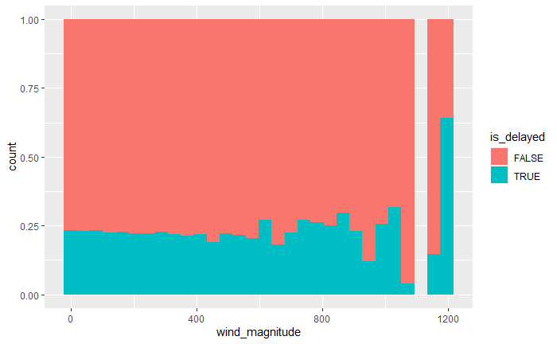

```r
flights %>%
  filter(!is.na(is_delayed)) %>%
  arrange(origin, time_hour) %>%
  select(time_hour, origin, is_delayed) %>%
  left_join(wind_deviance_mag, by = c("time_hour", "origin")) %>%
  ggplot(aes(x = wind_magnitude, fill = is_delayed)) +
  geom_histogram(position = "fill")
```

# Delays

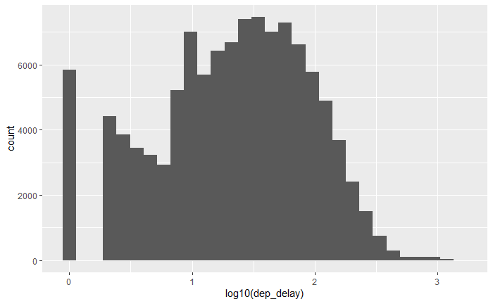

```r
# distribution of delays
flights %>%
  select(dep_delay) %>%
  ggplot(aes(x = log10(dep_delay))) +
  geom_histogram()
```

# Geospatial

```r
library(rnaturalearth)
library(rnaturalearthdata)
library(rgeos)
world <- ne_countries(scale = "medium", returnclass = "sf")

usa_polygon <- world %>%
  filter(name == "United States")


airports <- read_csv("clean_data/airports_clean.csv")
```

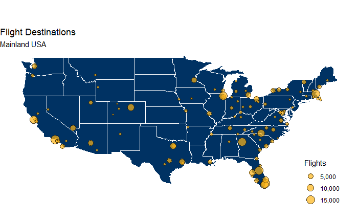

```r
ggplot(data=state) +
  geom_polygon(aes(x=long, y=lat, group=group),
               color = "white",
               fill = "#003263",
               alpha = 1) +
  guides(fill=FALSE) +
  theme_void() +
  geom_point(data = location_summary,
             aes(x = lon, y = lat, size = flights),
             fill = "#feb516",
             colour = "black",
             alpha = 0.7,
             shape = 21) +
  coord_sf(xlim = c(-125.6, -66.28), ylim = c(24.79, 49.45), expand = TRUE) +
  labs(title = "Flight Destinations",
       subtitle = "Mainland USA",
       size = "Flights") +
  scale_size(labels = scales::comma) +
  theme(legend.position = c(0.9,0.1))
```